# Ford GoBike System Presentation

## by (Bnina Ayoub)

## Investigation Overview

- In this investigation i wanted to explore the age range and it's duration average, Moreover i wanted to identify their types as well as their gender as members. My main focus was on the duration, the age, user type and member gender.

## Dataset Overview

- This data set includes information about individual rides made in a bike-sharing system covering the greater San Francisco Bay area. Where I made some modification like creating new features,cleaning and subsetting.

## Age Distribution

Distribution of members age are limited from 20s to 90s, A right skewed histogram with a peak between 25 and 35 values shows that most members are tricenarians.

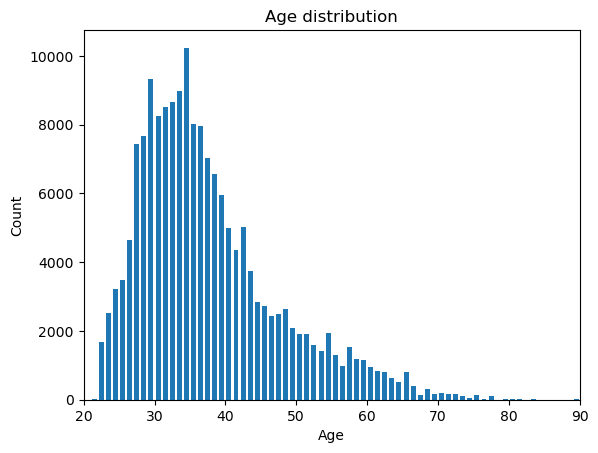

## Duration Distribution

Duration contains a a very large range of values, Plotted on the logarithmic scale we can see a Unimodal histogram with a normal distribution including a peak between 400 and 800.

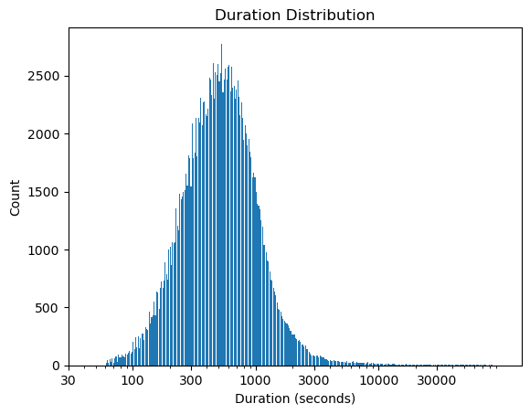

## Duration VS Age decades

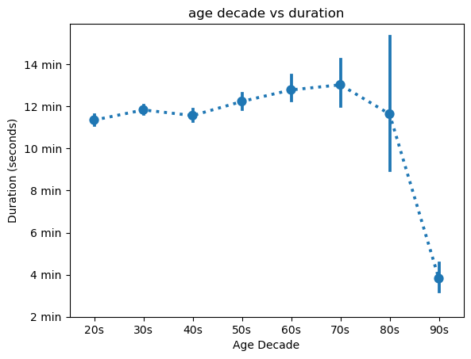

## Gender Proportion

Using a pie chart male's overall duration represents more than 70% comparing to the rest.

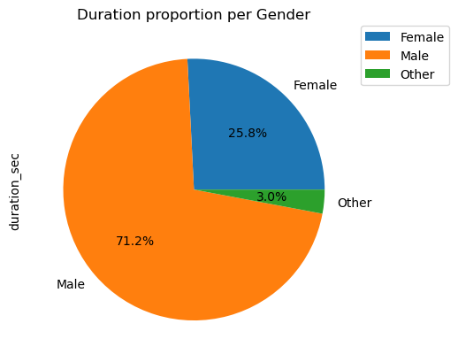

## User type Proportion

The dataset contains two user type customers and subscribers, As shown below subscribers represents more than 90% of participant, They usually take part of trip with less duration comparing to customers.

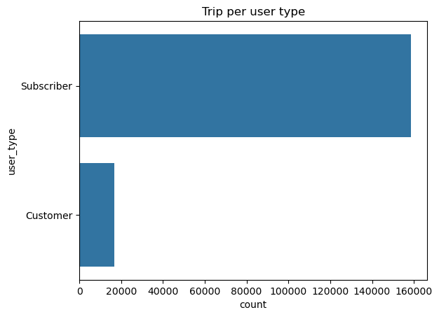